# Отчёт по лабораторной работе №12

Синхронизация времени

Бызова Мария Олеговна

2025-11-10

# Цель работы

## Цель работы

Целью данной лабораторной работы является получение навыков по управлению системным временем и настройке синхронизации времени.

# Выполнение лабораторной работы

## Проверка параметров времени на сервере

На сервере посмотрим параметры настройки даты и времени с помощью команды `timedatectl`, текущее системное время с помощью команды `date` и аппаратное время с помощью команды `hwclock` (рис. 1).

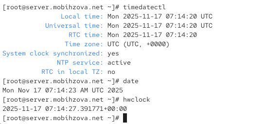

Рисунок 1: Проверка параметров времени на сервере

## Проверка параметров времени на клиенте

На клиенте также проверим параметры времени с помощью тех же команд (рис. 2).

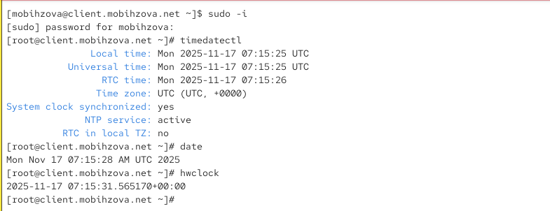

Рисунок 2: Проверка параметров времени на клиенте

## Управление синхронизацией времени

Установим необходимое программное обеспечение chrony на сервере (рис. 3).

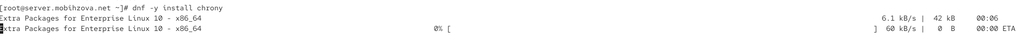

Рисунок 3: Установка chrony на сервере

## Установка chrony на клиенте

Установим chrony на клиенте (рис. 4).

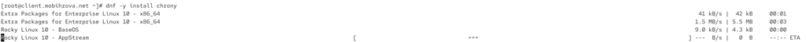

Рисунок 4: Установка chrony на клиенте

## Проверка исходных источников времени на сервере

Проверим источники времени на сервере до настройки (рис. 5).

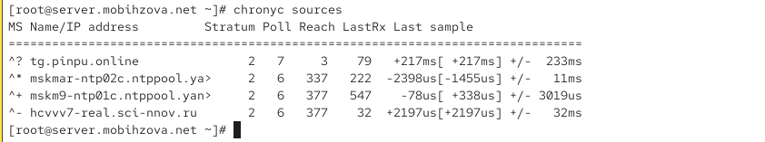

Рисунок 5: Проверка исходных источников времени на сервере

## Проверка исходных источников времени на клиенте

Проверим источники времени на клиенте до настройки (рис. 6).

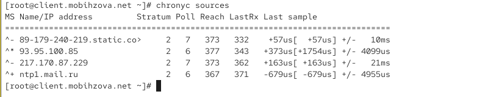

Рисунок 6: Проверка исходных источников времени на клиенте

## Настройка сервера chrony

На сервере отредактируем файл `/etc/chrony.conf` и добавим строку, разрешающую доступ клиентам из локальной сети (рис. 7).

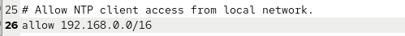

Рисунок 7: Настройка конфигурации сервера chrony

## Настройка сервера chrony

Перезапустим службу chronyd и настроим межсетевой экран (рис. 8).

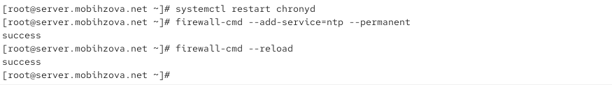

Рисунок 8: Перезапуск службы и настройка фаервола на сервере

## Настройка клиента chrony

На клиенте отредактируем файл `/etc/chrony.conf`, добавив строку с указанием сервера синхронизации и удалив все остальные строки с директивой server (рис. 9)

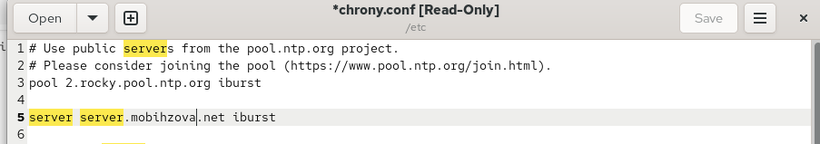

Рисунок 9: Конфигурационный файл chrony на клиенте

## Настройка клиента chrony

Перезапустим службу chronyd на клиенте (рис. 10).

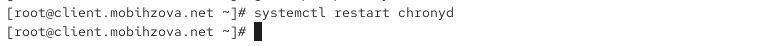

Рисунок 10: Перезапуск службы chronyd на клиенте

## Проверка синхронизации после настройки

Проверим источники времени на клиенте после настройки (рис. 11).

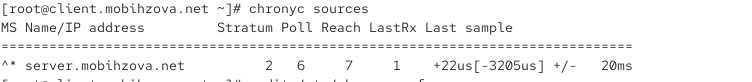

Рисунок 11: Проверка источников времени на клиенте после настройки

## Проверка синхронизации после настройки

Проверим источники времени на сервере после настройки (рис. 12).

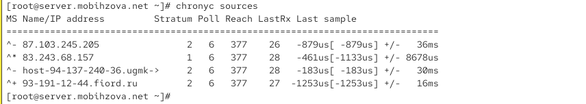

Рисунок 12: Проверка источников времени на сервере после настройки

## Детальная информация о синхронизации

Посмотрим подробную информацию о синхронизации на клиенте (рис. 13).

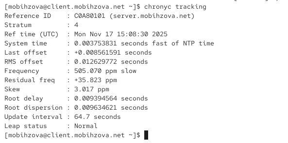

Рисунок 13: Детальная информация о синхронизации на клиенте

## Внесение изменений в настройки внутреннего окружения виртуальных машин

На виртуальной машине server перейдем в каталог для внесения изменений и создадим необходимые структуры каталогов (рис. 14).

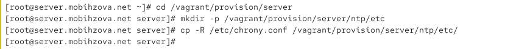

Рисунок 14: Создание структуры каталогов на сервере

## Внесение изменений в настройки внутреннего окружения виртуальных машин

Создадим исполняемый файл ntp.sh на сервере (рис. 15).

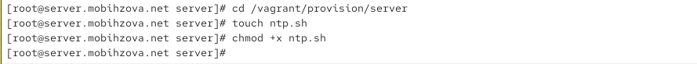

Рисунок 15: Создание скрипта ntp.sh на сервере

## Внесение изменений в настройки внутреннего окружения виртуальных машин

Настроим содержимое скрипта ntp.sh для сервера (рис. 16).

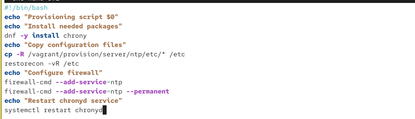

Рисунок 16: Содержимое скрипта ntp.sh для сервера

## Внесение изменений в настройки внутреннего окружения виртуальных машин

На виртуальной машине client создадим структуру каталогов для конфигурации (рис. 17).

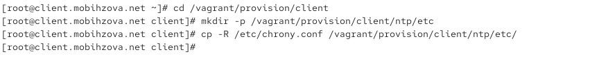

Рисунок 17: Создание структуры каталогов на клиенте

## Внесение изменений в настройки внутреннего окружения виртуальных машин

Создадим исполняемый файл ntp.sh на клиенте (рис. 18).

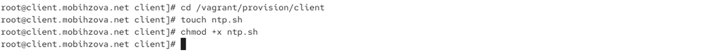

Рисунок 18: Создание скрипта ntp.sh на клиенте

## Внесение изменений в настройки внутреннего окружения виртуальных машин

Настроим содержимое скрипта ntp.sh для клиента (рис. 19).

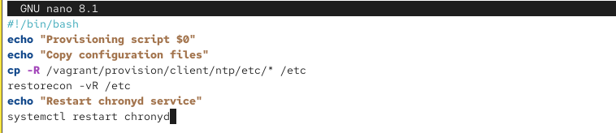

Рисунок 19: Содержимое скрипта ntp.sh для клиента

## Внесение изменений в настройки внутреннего окружения виртуальных машин

Добавим в конфигурационный файл Vagrantfile секции для автоматического выполнения скриптов при загрузке виртуальных машин (рис. 20, рис. 21).

## Внесение изменений в настройки внутреннего окружения виртуальных машин

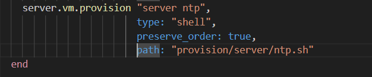

Рисунок 20: Конфигурация Vagrant для сервера

## Внесение изменений в настройки внутреннего окружения виртуальных машин

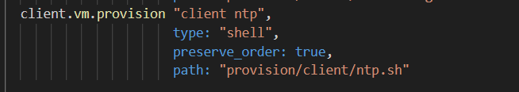

Рисунок 21: Конфигурация Vagrant для клиента

# Выводы

## Выводы

В ходе данной лабораторной работы я приобрела навыки по управлению системным временем и настройке синхронизации времени.